# Getting Started with NNS: Clustering and Regression

Fred Viole

```r
library(NNS)
require(knitr)
require(rgl)
```

# Clustering and Regression

Below are some examples demonstrating unsupervised learning with NNS clustering and nonlinear regression using the resulting clusters. As always, for a more thorough description and definition, please view the References.

## NNS Partitioning `NNS.part()`

**`NNS.part`** is both a partitional and hierarchical clustering method. `NNS` iteratively partitions the joint distribution into partial moment quadrants, and then assigns a quadrant identification (1:4) at each partition.

**`NNS.part`** returns a `data.frame` of observations along with their final quadrant identification. It also returns the regression points, which are the quadrant means used in **`NNS.reg`**.

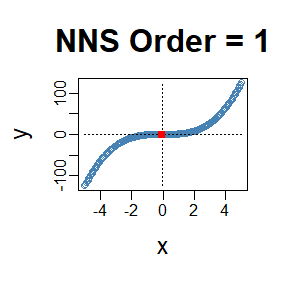

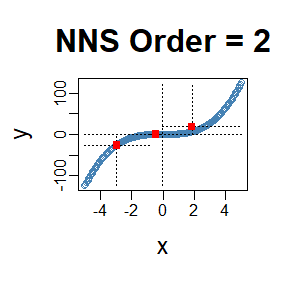

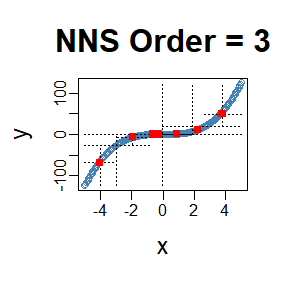

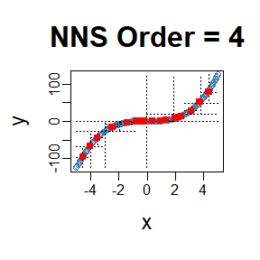

```r
x = seq(-5, 5, .05); y = x ^ 3

for(i in 1 : 4){NNS.part(x, y, order = i, Voronoi = TRUE, obs.req = 0)}
```

### X-only Partitioning

**`NNS.part`** offers a partitioning based on $x$ values only **`NNS.part(x, y, type = "XONLY", ...)`**, using the entire bandwidth in its regression point derivation, and shares the same limit condition as partitioning via both $x$ and $y$ values.

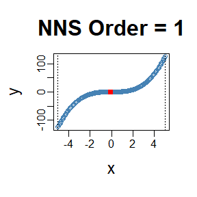

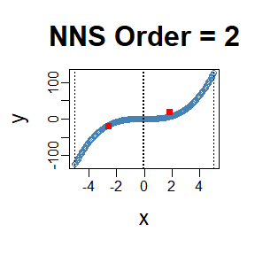

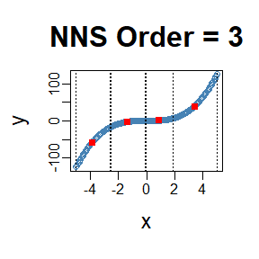

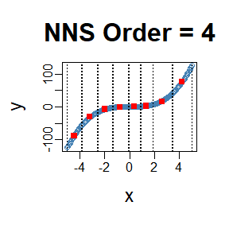

```r
for(i in 1 : 4){NNS.part(x, y, order = i, type = "XONLY", Voronoi = TRUE)}
```

Note the partition identifications are limited to 1’s and 2’s (left and right of the partition respectively), not the 4 values per the $x$ and $y$ partitioning.

[output not shown]

## Clusters Used in Regression

The right column of plots shows the corresponding regression (plus endpoints and central point) for the order of `NNS` partitioning.

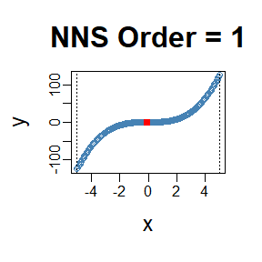

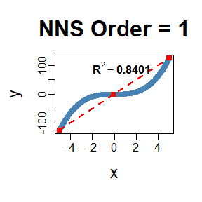

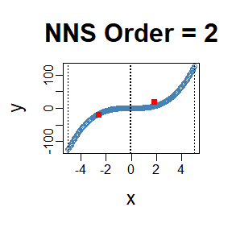

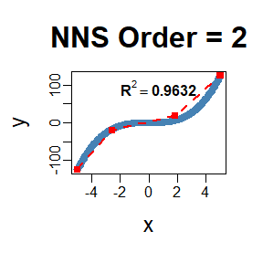

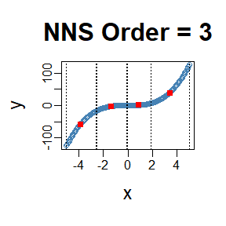

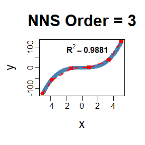

```r
for(i in 1 : 3){NNS.part(x, y, order = i, obs.req = 0, Voronoi = TRUE, type = "XONLY") ; NNS.reg(x, y, order = i, ncores = 1)}
```

# NNS Regression `NNS.reg()`

**`NNS.reg`** can fit any $f(x)$, for both uni- and multivariate cases. **`NNS.reg`** returns a self-evident list of values provided below.

## Univariate:

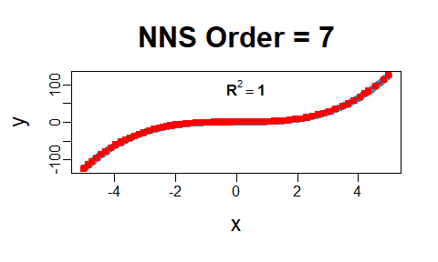

```
## $R2
## [1] 0.9999863
##
## $SE
## [1] 0.18182
##
## $Prediction.Accuracy
## NULL
##
## $equation
## NULL
##
## $x.star
## NULL
##
## $derivative
##   Coefficient X.Lower.Range X.Upper.Range
## 1    74.25250     -5.000000     -4.975000
## 2    72.47650     -4.975000     -4.850000
## 3    68.69350     -4.850000     -4.725000
## 4    64.88657     -4.725000     -4.585417
## 5    61.01481     -4.585417     -4.425000
## 6    57.64629     -4.425000     -4.287500
## ---
## 60    42.67514      3.843750      4.062500
## 61    57.09308      4.062500      4.225000
## 62    55.24079      4.225000      4.343750
## 63    59.68593      4.343750      4.567158
## 64    66.33741      4.567158      4.830103
## 65    72.01977      4.830103      5.000000
## --- [ 65 rows x 3 cols ]; showing first and last 6. Use as.data.frame(x) for all. ---
##
## $Point.est
## NULL
##
## $pred.int
## NULL
##
## $regression.points
##           x          y
```

[output cut: 21 more lines]

```
## 4 -4.85 -114.0841 -114.0841      3  68.6935   0.00000
## 5 -4.80 -110.5920 -110.6495      3  68.6935  -0.05745
## 6 -4.75 -107.1719 -107.2148      3  68.6935  -0.04290
## ---
##        x        y    y.hat NNS.ID gradient residuals
## 196 4.75 107.1719 107.4502     64 66.33741 0.2783568
## 197 4.80 110.5920 110.7671     64 66.33741 0.1751022
## 198 4.85 114.0841 114.1970     65 72.01977 0.1129090
## 199 4.90 117.6490 117.7980     65 72.01977 0.1490227
## 200 4.95 121.2874 121.3990     65 72.01977 0.1116363
## 201 5.00 125.0000 125.0000     65 72.01977 0.0000000
## --- [ 201 rows x 6 cols ]; showing first and last 6. Use as.data.frame(x) for all. ---
##
## $class.levels
## NULL
```

```r
NNS.reg(x, y, ncores = 1)
```

## Multivariate:

Multivariate regressions return a plot of $y$ and $\hat{y}$, as well as the regression points (`$RPM`) and partitions (`$rhs.partitions`) for each regressor.

```r
f = function(x, y) x ^ 3 + 3 * y - y ^ 3 - 3 * x
y = x ; z <- expand.grid(x, y)
g = f(z[ , 1], z[ , 2])
NNS.reg(z, g, order = "max", plot = FALSE, ncores = 1)
```

```
## $R2
## [1] 1
##
## $rhs.partitions
##    Var1  Var2
## 1 -5.00 -5.00
## 2 -4.95 -4.95
## 3 -4.90 -4.90
## 4 -4.85 -4.85
## 5 -4.80 -4.80
## 6 -4.75 -4.75
## ---
##     Var1 Var2
## 196 4.75 4.75
## 197 4.80 4.80
## 198 4.85 4.85
## 199 4.90 4.90
## 200 4.95 4.95
## 201 5.00 5.00
## --- [ 201 rows x 2 cols ]; showing first and last 6. Use as.data.frame(x) for all. ---
##
## $RPM
##   Var1  Var2      y.hat
## 1   -5 -5.00    0.00000
## 2   -5 -4.55  -29.45363
## 3   -5 -0.05 -110.14988
## 4   -5  0.00 -110.00000
## 5   -5  0.05 -109.85012
## 6   -5  0.10 -109.70100
## ---
##       Var1  Var2     y.hat
## 40396 -0.1 -0.35 -0.708125
## 40397 -0.1 -0.30 -0.574000
## 40398 -0.1 -0.25 -0.435375
## 40399 -0.1 -0.20 -0.293000
## 40400 -0.1 -0.15 -0.147625
## 40401 -0.1 -0.10  0.000000
## --- [ 40401 rows x 3 cols ]; showing first and last 6. Use as.data.frame(x) for all. ---
##
## $Point.est
```

[output cut: 13 more lines]

```
## ---
##       Var1 Var2          y      y.hat  NNS.ID residuals
## 40396 4.75    5 -17.078125 -17.078125 196.201         0
## 40397 4.80    5 -13.808000 -13.808000 197.201         0
## 40398 4.85    5 -10.465875 -10.465875 198.201         0
## 40399 4.90    5  -7.051000  -7.051000 199.201         0
## 40400 4.95    5  -3.562625  -3.562625 200.201         0
## 40401 5.00    5   0.000000   0.000000 201.201         0
## --- [ 40401 rows x 6 cols ]; showing first and last 6. Use as.data.frame(x) for all. ---
##
## $n.best
## [1] 1
##
## $dist
## [1] "NNS"
```

## Inter/Extrapolation

`NNS.reg` can inter- or extrapolate any point of interest. The **`NNS.reg(x, y, point.est = ...)`** parameter permits any sized data of similar dimensions to $x$ and called specifically with **`NNS.reg(...)$Point.est`**.

## NNS Dimension Reduction Regression

**`NNS.reg`** also provides a dimension reduction regression by including a parameter **`NNS.reg(x, y, dim.red.method = "cor", ...)`**. Reducing all regressors to a single dimension using the returned equation **`NNS.reg(..., dim.red.method = "cor", ...)$equation`**.

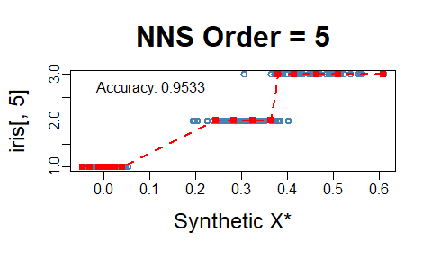

```
##       Variable Coefficient
## 1 Sepal.Length   0.7980781
## 2  Sepal.Width  -0.4402896
## 3 Petal.Length   0.9354305
## 4  Petal.Width   0.9381792
## 5  DENOMINATOR   4.0000000
```

```r
NNS.reg(iris[ , 1 : 4], iris[ , 5], dim.red.method = "cor", location = "topleft", ncores = 1)$equation
```

Thus, our model for this regression would be:
$$Species = \frac{0.798*Sepal.Length
-0.44*Sepal.Width +0.935*Petal.Length +0.938*Petal.Width}{4}$$

### Threshold

**`NNS.reg(x, y, dim.red.method = "cor", threshold = ...)`** offers a method of reducing regressors further by controlling the absolute value of required correlation.

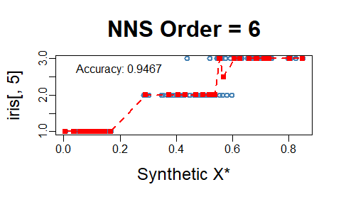

```
##       Variable Coefficient
## 1 Sepal.Length   0.7980781
## 2  Sepal.Width   0.0000000
## 3 Petal.Length   0.9354305
## 4  Petal.Width   0.9381792
## 5  DENOMINATOR   3.0000000
```

```r
NNS.reg(iris[ , 1 : 4], iris[ , 5], dim.red.method = "cor", threshold = .75, location = "topleft", ncores = 1)$equation
```

Thus, our model for this further reduced dimension regression would be:
$$Species = \frac{\: 0.798*Sepal.Length +
0*Sepal.Width +0.935*Petal.Length +0.938*Petal.Width}{3}$$

and the `point.est = (...)` operates in the same manner as the full regression above, again called with **`NNS.reg(...)$Point.est`**.

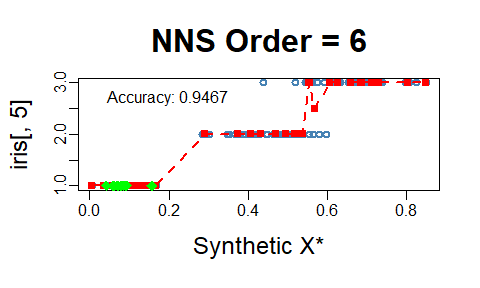

```
##  [1] 1 1 1 1 1 1 1 1 1 1
```

```r
NNS.reg(iris[ , 1 : 4], iris[ , 5], dim.red.method = "cor", threshold = .75, point.est = iris[1 : 10, 1 : 4], location = "topleft", ncores = 1)$Point.est
```

# Classification

For a classification problem, we simply set **`NNS.reg(x, y, type = "CLASS", ...)`**.

**NOTE: Base category of response variable should be 1, not 0 for classification problems.**

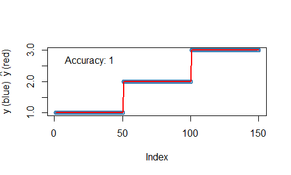

```
##  [1] 1 1 1 1 1 1 1 1 1 1
```

```r
NNS.reg(iris[ , 1 : 4], iris[ , 5], type = "CLASS", point.est = iris[1 : 10, 1 : 4], location = "topleft", ncores = 1)$Point.est
```

# Cross-Validation `NNS.stack()`

The **`NNS.stack`** routine cross-validates for a given objective function the `n.best` parameter in the multivariate **`NNS.reg`** function as well as the `threshold` parameter in the dimension reduction **`NNS.reg`** version. **`NNS.stack`** can be used for classification:

**`NNS.stack(..., type = "CLASS", ...)`**

or continuous dependent variables:

**`NNS.stack(..., type = NULL, ...)`**.

Any objective function `obj.fn` can be called using `expression()` with the terms `predicted` and `actual`, even from external packages such as `Metrics`.

**`NNS.stack(..., obj.fn = expression(Metrics::mape(actual, predicted)), objective = "min")`**.

```r
NNS.stack(IVs.train = iris[ , 1 : 4],
          DV.train = iris[ , 5],
          IVs.test = iris[1 : 10, 1 : 4],
          dim.red.method = "cor",
          obj.fn = expression( mean(round(predicted) == actual) ),
          objective = "max", type = "CLASS",
          folds = 1, ncores = 1)
```

```r
Method 2 fold 1/1: generating 4 cumulative projections
Method 2 fold 1/1: evaluating 4 unique candidates
Method 2 fold 1/1 complete
Current dimension count = 1 | OOF eval(obj.fn) = 0.944444 | Iterations remaining = 3
Current dimension count = 2 | OOF eval(obj.fn) = 0.972222 | Iterations remaining = 2
Current dimension count = 3 | OOF eval(obj.fn) = 0.944444 | Iterations remaining = 1
Current dimension count = 4 | OOF eval(obj.fn) = 0.916667 | Iterations remaining = 0
Method 1 fold 1/1: preparing fold design
Method 1 fold 1/1: building partitions
RPM rows = 29; validation rows = 36
  small candidates = 1...12
  early stopping at k = 4
  limit candidate = all (k = 29), score = 0.333333
Best Method 1 candidate: k = 2, score = 0.972222
Generating final estimates
$OBJfn.reg
        2
0.9722222

$NNS.reg.n.best
[1] 2

$probability.threshold
[1] 0.48

$OBJfn.dim.red
[1] 0.9722222

$NNS.dim.red.threshold
[1] 0.9354305

$reg
 [1] 1 1 1 1 1 1 1 1 1 1

$reg.pred.int
NULL

$dim.red
 [1] 1 1 1 1 1 1 1 1 1 1

$dim.red.pred.int
NULL

$stack
 [1] 1 1 1 1 1 1 1 1 1 1

$pred.int
NULL

$weights
    reg dim.red
    0.5     0.5

$class.levels
[1] "setosa"     "versicolor" "virginica"
```

# Increasing Dimensions

Given multicollinearity is not an issue for nonparametric regressions as it is for OLS, in the case of an ill-fit univariate model a better option may be to increase the dimensionality of regressors with a copy of itself and cross-validate the number of clusters `n.best` via:

**`NNS.stack(IVs.train = cbind(x, x), DV.train = y, method = 1, ...)`**.

```r
set.seed(123)
x = rnorm(100); y = rnorm(100)

nns.params = NNS.stack(IVs.train = cbind(x, x),
                        DV.train = y,
                        method = 1, ncores = 1)
```

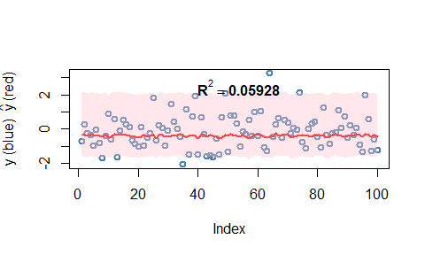

```r
NNS.reg(cbind(x, x), y,
        n.best = nns.params$NNS.reg.n.best,
        point.est = cbind(x, x),
        residual.plot = TRUE,
        ncores = 1, confidence.interval = .95)
```

# Smoothing Option

Smoothness is not required for curve fitting, but the `NNS.reg` function offers an optional smoothed fit. This feature applies a smoothing spline to regression points generated internally using the partitioning method described earlier.

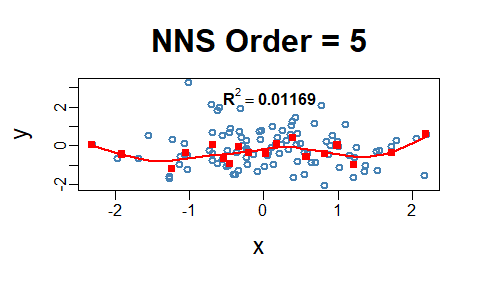

```r
NNS.reg(x, y, smooth = TRUE)
```

# Imputation

Imputation in `NNS` is a direct application of nearest neighbor regression. When values of $y$ are missing, we use the observed $(X,y)$ pairs as the training set and the predictors of the missing rows as `point.est`.

A key insight is that even in univariate regressions, `NNS.reg` benefits from the increasing dimensions trick: by duplicating the predictor into a multivariate form, e.g. `cbind(x, x)`, the distance function underlying `NNS.reg` operates in a 2-D space. This sharpened distance metric allows a more robust donor selection, effectively turning univariate imputation into a special case of multivariate nearest neighbor regression.

For multivariate predictors, the same form applies directly — supply the full set of observed predictors in $x$, the observed responses in $y$, and the incomplete rows in `point.est`. With `order = "max", n.best = 1`, the imputation is always 1-NN donor-based: each missing $y$ is filled in by the response of its closest donor under the `NNS` hybrid distance. This ensures imputations remain strictly within the support of the observed data.

**Categorical data** is handled analogously, only requiring `NNS.reg(..., type = "CLASS")` in the procedure.

## Univariate Imputation

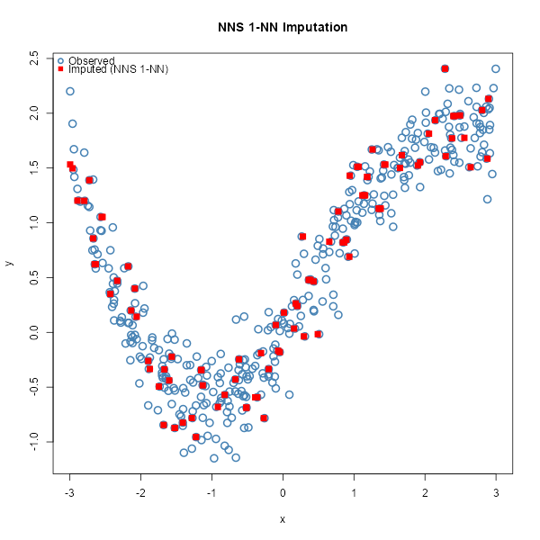

```r
set.seed(123)

# Univariate predictor with nonlinear signal
n <- 400
x <- sort(runif(n, -3, 3))
y <- sin(x) + 0.2 * x^2 + rnorm(n, 0, 0.25)

# Induce ~25% MCAR missingness in y
miss <- rbinom(n, 1, 0.25) == 1
y_mis <- y
y_mis[miss] <- NA

# ---- Increasing dimensions trick ----
# Duplicate x so the distance operates in a 2D space: cbind(x, x).
# This sharpens nearest-neighbor selection even in a nominally univariate setting.
x2_train <- cbind(x[!miss], x[!miss])
x2_miss  <- cbind(x[miss],  x[miss])

# 1-NN donor imputation with NNS.reg
y_hat_uni <- NNS::NNS.reg(
  x         = x2_train,             # predictors (duplicated x)
  y         = y[!miss],             # observed responses
  point.est = x2_miss,              # rows to impute
  order     = "max",                # dependence-maximizing order
  n.best    = 1,                    # 1-NN donor
  plot      = FALSE
)$Point.est

# Fill back
y_completed_uni <- y_mis
y_completed_uni[miss] <- y_hat_uni

# Plot observed vs imputed (NNS 1-NN)
plot(x, y, pch = 1, col = "steelblue", cex = 1.5, lwd = 2,
     xlab = "x", ylab = "y", main = "NNS 1-NN Imputation")
points(x[miss], y_hat_uni, col = "red", pch = 15, cex = 1.3)

legend("topleft",
       legend = c("Observed", "Imputed (NNS 1-NN)"),
       col    = c("steelblue", "red"),
       pch    = c(1, 15),
       pt.lwd = c(2, NA),
       bty    = "n")
```

## Multivariate Imputation

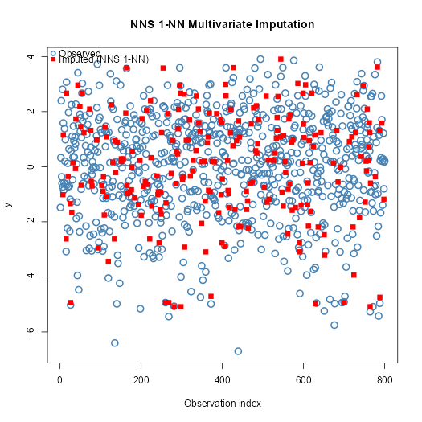

```r
set.seed(123)

# Multivariate predictors with nonlinear & interaction structure
n <- 800
X <- cbind(
  x1 = rnorm(n),
  x2 = runif(n, -2, 2),
  x3 = rnorm(n, 0, 1)
)

f <- function(x1, x2, x3) 1.1*x1 - 0.8*x2 + 0.5*x3 + 0.6*x1*x2 - 0.4*x2*x3 + 0.3*sin(1.3*x1)
y <- f(X[,1], X[,2], X[,3]) + rnorm(n, 0, 0.4)

# Induce ~30% MCAR missingness in y
miss <- rbinom(n, 1, 0.30) == 1
y_mis <- y
y_mis[miss] <- NA

# Training (observed) vs rows to impute
X_obs <- X[!miss, , drop = FALSE]
y_obs <- y[!miss]
X_mis <- X[ miss, , drop = FALSE]

# 1-NN donor imputation with NNS.reg
y_hat_mv <- NNS::NNS.reg(
  x         = X_obs,     # all observed predictors
  y         = y_obs,     # observed responses
  point.est = X_mis,     # rows to impute
  order     = "max",     # dependence-maximizing order
  n.best    = 1,         # 1-NN donor
  plot      = FALSE
)$Point.est

# Completed vector
y_completed_mv <- y_mis
y_completed_mv[miss] <- y_hat_mv

# Plot observed vs imputed (multivariate, NNS 1-NN)
plot(seq_along(y), y,
     pch = 1, col = "steelblue", cex = 1.5, lwd = 2,
     xlab = "Observation index", ylab = "y",
     main = "NNS 1-NN Multivariate Imputation")

# Overlay imputed values
points(which(miss), y_hat_mv, pch = 15, col = "red", cex = 1.2)

# Legend
legend("topleft",
       legend = c("Observed", "Imputed (NNS 1-NN)"),
       col    = c("steelblue", "red"),
       pch    = c(1, 15),
       pt.lwd = c(2, NA),
       bty    = "n")
```

## A Note on Uncertainty Propagation

A common concern with local imputation methods is whether imputation uncertainty propagates correctly into downstream inference. `NNS` addresses this through bootstrap multiple imputation: resampling complete cases across `m` iterations generates between-imputation variance that flows through standard Rubin’s rules pooling identically to any classical procedure.

Empirically, `NNS` bootstrap MI outperforms MICE with predictive mean matching on nonlinear data — producing a pooled estimate closer to the true parameter with a smaller pooled SE. The advantage comes not from compressing uncertainty but from a more accurate imputation model, which reduces between-imputation variance driven by model error rather than genuine data uncertainty.

See [NNS Multiple Imputation vs MICE](https://github.com/OVVO-Financial/NNS/blob/NNS-Beta-Version/examples/NNS_MI_vs_MICE.md) for the full reproducible comparison.

# References

If the user is so motivated, detailed arguments further examples are provided within the following:

- [Nonlinear Nonparametric Statistics: Using Partial Moments](https://ovvo-financial.github.io/NNS/book/)
- [Deriving Nonlinear Correlation Coefficients from Partial Moments](https://doi.org/10.2139/ssrn.2148522)
- [Nonparametric Regression Using Clusters](https://doi.org/10.1007/s10614-017-9713-5)
- [Clustering and Curve Fitting by Line Segments](https://doi.org/10.2139/ssrn.2861339)
- [Classification Using NNS Clustering Analysis](https://doi.org/10.2139/ssrn.2864711)
- [Partitional Estimation Using Partial Moments](https://doi.org/10.2139/ssrn.3592491)